# Assignment 4

# To view and understand this model, we plot this using fviz_cluster() method

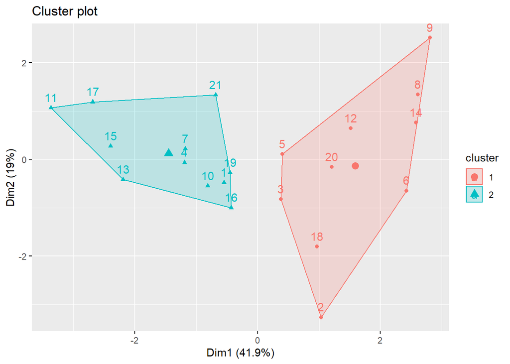

```r
fviz_cluster(kmeans_model, data = data_df_scale)
```

###Since we know that K is a hyperparameter that the user needs to set, we will run several iterationd of Kmeans algo, each time changing the value of K. #This will help us find the optimal value of K.

```r
kmeans_model3 <- kmeans(data_df_scale, centers = 3, nstart = 25)
kmeans_model4 <- kmeans(data_df_scale, centers = 4, nstart = 25)
kmeans_model5 <- kmeans(data_df_scale, centers = 5, nstart = 25)
kmeans_model6 <- kmeans(data_df_scale, centers = 6, nstart = 25)
kmeans_model7 <- kmeans(data_df_scale, centers = 7, nstart = 25)
```

#Plots for comparing

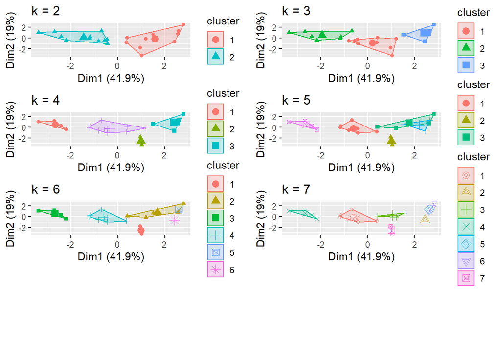

```r
n1 <- fviz_cluster(kmeans_model,  geom = "point",  data = data_df_scale) + ggtitle("k = 2")
n2 <- fviz_cluster(kmeans_model3, geom = "point",  data = data_df_scale) + ggtitle("k = 3")
n3 <- fviz_cluster(kmeans_model4, geom = "point",  data = data_df_scale) + ggtitle("k = 4")
n4 <- fviz_cluster(kmeans_model5, geom = "point",  data = data_df_scale) + ggtitle("k = 5")
n5 <- fviz_cluster(kmeans_model6, geom = "point",  data = data_df_scale) + ggtitle("k = 6")
n6 <- fviz_cluster(kmeans_model7, geom = "point",  data = data_df_scale) + ggtitle("k = 7")
library(gridExtra)
grid.arrange(n1, n2, n3, n4, n5, n6, nrow = 4)
```

###Now as the graph depicts, we find ourself in new type of situation. #This situation is to decide which value of k to consider? #Thankfully, we have 3 methods to determine this. #These methods are: 1. Elbow method 2. Silhouette method 3. Gap statistic

###In this scenario we will use the Elbow method. We will consider the value of k, where there is bend in the plot.We use fviz_nbclust() method, which calculates this for us.

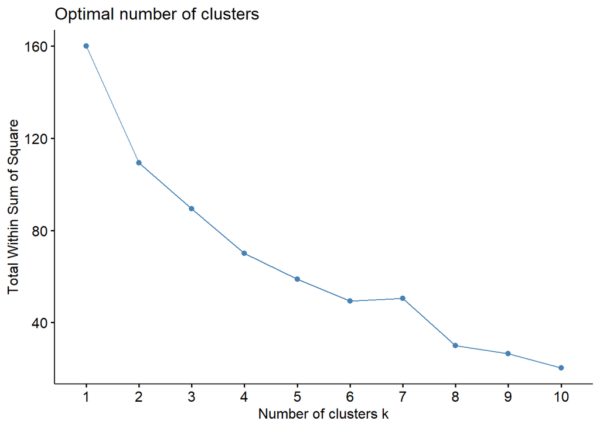

```r
set.seed(123)
fviz_nbclust(data_df_scale, kmeans, method = "wss")
```

Here we will not use k = 7 as the value goes up before going down. So we will choose k = 5.

# Similarly we calculate Silhouette method and Gap statistic.

Silhouette method This method determines how well an object lies in a cluster. In this, a high average silhouette width indicates good clustering.

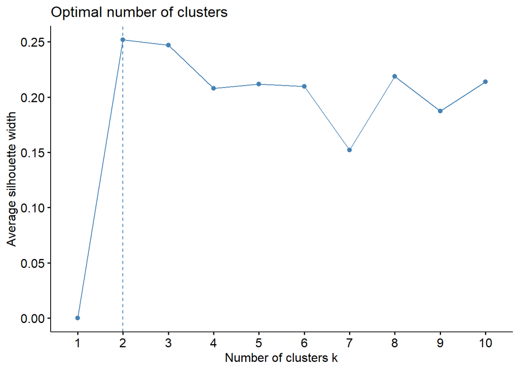

```r
fviz_nbclust(data_df_scale, kmeans, method = "silhouette")
```

###As we can see, the Silhouette method gives us 2 clusters.

#Now we can extract the final result for our kmeans method #by setting value of k = 5 (For Euclidean Method)

```r
set.seed(123)
final_model <- kmeans(data_df_scale, 5, nstart = 25)
print(final_model)
```

```
## K-means clustering with 5 clusters of sizes 2, 3, 8, 4, 4
##
## Cluster means:
##    Market_Cap       Beta    PE_Ratio        ROE        ROA Asset_Turnover
## 1 -0.43925134 -0.4701800  2.70002464 -0.8349525 -0.9234951      0.2306328
## 2 -0.87051511  1.3409869 -0.05284434 -0.6184015 -1.1928478     -0.4612656
## 3 -0.03142211 -0.4360989 -0.31724852  0.1950459  0.4083915      0.1729746
## 4  1.69558112 -0.1780563 -0.19845823  1.2349879  1.3503431      1.1531640
## 5 -0.76022489  0.2796041 -0.47742380 -0.7438022 -0.8107428     -1.2684804
##      Leverage Rev_Growth
## 1 -0.14170336 -0.1168459
## 2  1.36644699 -0.6912914
## 3 -0.27449312 -0.7041516
## 4 -0.46807818  0.4671788
## 5  0.06308085  1.5180158
##
## Clustering vector:
##  1  2  3  4  5  6  7  8  9 10 11 12 13 14 15 16 17 18 19 20 21
##  3  1  3  3  5  2  3  2  5  3  4  2  4  5  4  3  4  1  3  5  3
##
## Within cluster sum of squares by cluster:
## [1]  2.765883 14.769026 18.466446  7.734337 11.739016
##  (between_SS / total_SS =  65.3 %)
##
## Available components:
##
## [1] "cluster"      "centers"      "totss"        "withinss"     "tot.withinss"
## [6] "betweenss"    "size"         "iter"         "ifault"
```

###And we can visualize the result using fviz_cluster()

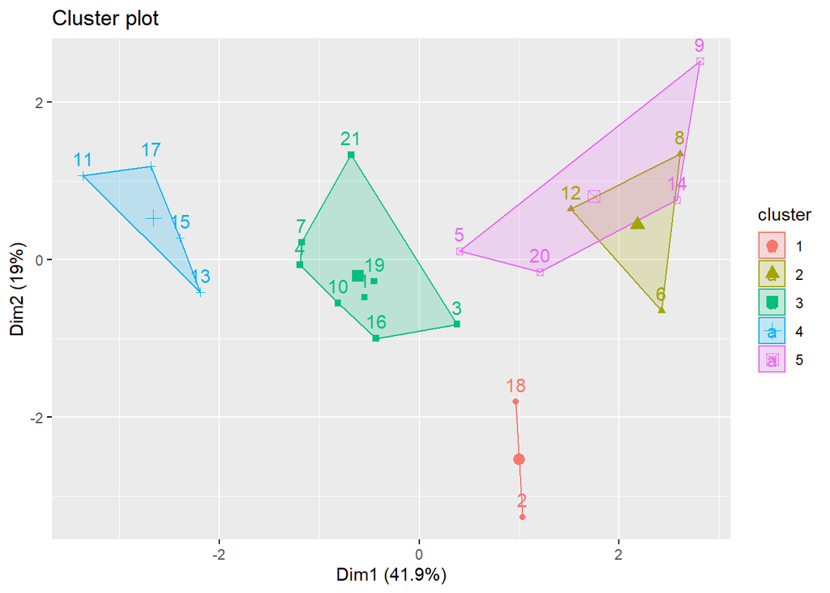

```r
fviz_cluster(final_model, data = data_df_scale)
```

#We can also take k = 2 for our final result and see what result we get by that (For Silhouette method).

```r
set.seed(123)
final_model2 <- kmeans(data_df_scale, 2, nstart = 25)
print(final_model2)
```

```
## K-means clustering with 2 clusters of sizes 11, 10
##
## Cluster means:
##   Market_Cap       Beta   PE_Ratio        ROE        ROA Asset_Turnover
## 1  0.6733825 -0.3586419 -0.2763512  0.6565978  0.8344159      0.4612656
## 2 -0.7407208  0.3945061  0.3039863 -0.7222576 -0.9178575     -0.5073922
##     Leverage Rev_Growth
## 1 -0.3331068 -0.2902163
## 2  0.3664175  0.3192379
##
## Clustering vector:
##  1  2  3  4  5  6  7  8  9 10 11 12 13 14 15 16 17 18 19 20 21
##  1  2  2  1  2  2  1  2  2  1  1  2  1  2  1  1  1  2  1  2  1
##
## Within cluster sum of squares by cluster:
## [1] 40.05664 69.26750
##  (between_SS / total_SS =  31.7 %)
##
## Available components:
##
## [1] "cluster"      "centers"      "totss"        "withinss"     "tot.withinss"
## [6] "betweenss"    "size"         "iter"         "ifault"
```